# Vanguerieae Report

Phylogenomics

Author

Friederike Wölke

Published

November 3, 2026

# 1 To DOs:

- Write introduction
- Write lab methods
- Re-do phylo inference in RevBayes
- Figure out dating, fossils etc

# 2 Introduction

- Info about Vanguerieae
- Dioecy evolution!
- Fossils for dating :)

# 3 Materials & Methods

### 3.0.1 Taxonomic summary:

Note: Numbers of accepted species is based on World Flora Online (2026)

| Rank | Scientific Name | Accepted species |
| --- | --- | --- |
| Order | Gentianales Juss. ex Bercht. & J.Presl | 23,438 |
| Family | Rubiaceae Juss. | 14,256 |
| Subfamily | Dialypetalanthoideae Reveal | 5,956 |
| Tribe | Vanguerieae Dumort. | 674 |

### 3.0.2 Data summary:

The project combines Angiosperm353 (Johnson et al. 2019) sequence data from three different sources. The tribe Vanguerieae comprises 28 currently accepted genera (World Flora Online 2026).

> *[NOTE] TO DO:* double-check number of genera in the data sets for ACCEPTED species names

[output not shown]

## 3.1 Sampling

Plant tissue material for datasets 1 and 2 was collected from herbarium materials or silica-collections (see supplementary for references for all samples).

## 3.2 Target Capture

MyBaits Angiosperm353 baits kit

## 3.3 Bioinformatics

The bioinformatics pipeline was developed in bash language. We used the captus pipeline (Ortiz et al. 2026) for QC, trimming, de-novo assembly, gene extraction, and alignment. For inference of concatenation-based species trees we used iqtree3, and ASTRAL. Figures were made in R 4.5.3.

### 3.3.1 Data retrieval

Sequence data published through the European Nucelotide Archive (ENA) from the PAFTOL project (Baker et al. 2022) were accessed and retrieved on October 23, 2026. Accession numbers can be found in the supplementary.

### 3.3.2 Quality control and sequence cleaning

#### 3.3.2.1 Trimming

We used the captus function `captus clean` using the flag `--qc_program fastqc` . captus uses bbduk.sh from BBTools (Bushnell 2014) with specific settings that balance speed and accuracy. The BBTools approach in Captus has been compared to other frequently used software for trimming and was by far the fastest and most accurate approach. More accurate was only Cutadapt (Martin 2011) but it took more than 23x longer. The increase in accuracy using Cutadapt was minimal compared to captus (perfectly correct trimming of bases: 96.9 % vs. 95.1%) Faster was only bbduk with default setting but it was less accurate (93.9% perfectly correct trimming of bases). For details, please refer to their [documentation](https://edgardomortiz.github.io/captus.docs/assembly/clean/). Trimming was then evaluated using FastQC (Andrews 2019) as implemented in Captus.

### 3.3.3 De-Novo Assembly

We used the captus function `captus assemble` with default options for de-novo assembly of raw trimmed reads into overlapping contigs.

In contrast to other commonly used tools and software (e.g., HybPiper) (Johnson et al. 2016), captus performs de-novo assembly into contigs using MEGAHIT (Li et al. 2015, 2016) before mapping the reads to a target sequence. This means that MEGAHIT combines information of overlapping reads into contigs. MEGAHIT is fast and memory efficient due to the use of succint De Bruijn Graph (sDBG) data structures. For detailed accurate calculations of contig depth of coverage Salmon (v 1.10.3) (Patro et al. 2017) is used and contigs with less than 1.5x coverage are automatically removed.

De-novo assembly increases the recovery and decreases the reference bias, especially for sequences that are not phylogenetically close to the sequences used in bait design. Comparing de-novo assembled contigs to the reference sequence is beneficial as it compares more complete loci, fewer missing bases, and longer sequences compared to using raw reads. In addition, it increases the recovery of non-baited sequences (off-target nuclear genes, plastomes, non-coding regions).

### 3.3.4 Mapping and extracting reference markers

Next, captus uses Scipio (Keller et al. 2008) to search and extract the reference sequences within the assembled contigs. The reference can be chosen by the user. We use the captus function `captus extract` with the flags `-n Mega353` `-p SeedPlantPTD` and `-m SeedPlantMIT`, which are three different references for nuclear (Mega353) (McLay et al. 2021), plastome (PTD) and mitochondrial (MIT) sequences. The Mega353 dataset contains multiple reference sequences per genes coming from a larger sample of clades, thereby increasing hits for sequences which are distant to the original target sequences. The two organellar datasets are a set of proteins across all seed plants curated by the Captus developers.

### 3.3.5 Alignment

We aligned the extracted markers using the captus function `captus align` with the flags `-m ALL` `-f ALL` `–-filter_method informed` `–-clipkit_method smart-gap`. captus first gathers all markers across all samples and uses the reference database for assisted alignment as a guide. By default, the function uses MAFFT (Katoh et al. 2002) with automatic model selection for the alignment. The flags `-m ALL` chooses all marker types for alignment (nuclear, plastome, mitochondrial) and `-f ALL` creates output in the formats: 1) coding sequences in amino acids, 2) coding sequences in nucleotides, 3) complete genes (intros + exons) without flanking regions, 4) complete genes with flanking regions. Nucleotide markers are aligned using the amino acid alignment as a template to take into account codons for the alignments. After alignment, the function also filters paralogs, trims erroneous stretches using TAPER (Zhang et al. 2021), and then removes the gaps in columns with ClipKIT (Steenwyk et al. 2020).

The flag `--filter_method informed` selects a method for handling paralogs. The method “informed” keeps only the copy that is most similar to the reference sequence that was most frequently chosen across all samples in the alignment. This method benefits from multiple reference sequences per locus while disregarding the ranking of best hits.

The flag `--clipkit_method smart-gap` selects the clipping method for gappy columns to dynamically determine the threshold for gaps (the recommended trimming mode in ClipKIT).

## 3.4 Phylogenomic inference

We used the aligned genes with flanking regions during phylogenomic inference of the concatenation and MSC nuclear trees. For organellar genomes, we used the aligned nucleotides as these alignments showed slightly more informative sites when compared to the genes with flanking regions. The aligned nucleotides are codon-aware and only include exons as they were aligned using the amino acid alignment as guide.

### 3.4.1 A) Summary trees using concatenation in IQ-TREE

We used edge-linked proportional partition models (Chernomor, Haeseler, and Minh 2016) and performed automated model selection for substitution models in iqtree version 3.1.4 (Wong et al. 2026).Compared to the edge-linked equal branch-length partition model and the edge-unlinked partition model, the proportional branch-length model allows partitions to differ in their overall evolutionary rates while retaining proportional branch lengths across the shared tree, thereby creating a reasonable compromise between flexibility and parameter complexity. We used the following flags for nuclear, plastid and mitochondrial markers: `-m MFP` `--ufboot 1000` which selects the extended model selection using modelfinder (Kalyaanamoorthy et al. 2017) that also includes free rate models and is immediately followed by tree reconstruction using the best model. This was performed using ultra fast bootstrap (UFBoot) (Hoang et al. 2018) with 1000 replicates.  
As a second approach we performed a maximum likelihood phylogenetic analysis using automated model selection, partition merging, and ultra fast bootstrap support estimation. For this we used the flags `-p` with the folder of individual alignments per extracted marker, `-m MFP+MERGE` for modelfinder comparison and partition merging, and `--ufboot 1000` to perform 1000 ultra fast bootstrap repetitions. iqtree3 then combines the individual gene alignments into a supermatrix where each gene is then initially treated as a separate partition. Following assessment of the similarity of evolutionary patterns, the model then merges multiple partitions (i.e., loci) to perform model selection once, thereby reducing the number of parameters the model has to estimate.  
The benefits of partition merging is that it allows for different substitution rates across partitions (i.e., different genetic markers) while still assuming a shared underlying tree topology across the partitions. Different genes may be more or less evolutionarily conserved and thereby evolve under different processes. Assuming a single substitution model across these different regions of the genome may not adequately represent these differences. Our approach instead let’s modelfinder as implemented in iqtree3 evaluate a set of models for each partition (i.e., alignment file in the folder) while the merging algorithm evaluates whether partitions can be combined under the same substitution model to decrease the number of substitution models to estimate. Model selection was then performed using the Bayesian Information Criterion (BIC) to avoid over-fitting to more complex models. Overall this approach reduces over-parameterization by combining partitions with similar evolutionary characteristics, improves the computational efficiency because fewer partitions and model parameters reduce computational time and memory requirements, balances model complexity and statistical fit by aiming to retain biologically relevant differences while avoiding unnecessary complexity and is hence particularly valuable for concatenated datasets containing many genes. One drawback is that for the estimation of individual gene trees, the +MERGE flag has to be removed, else the model will merge similar loci and thereby create less than 353 gene trees.

### 3.4.2 B) MSC-aware inference of a species tree from nuclear gene trees in wASTRAL

First we inferred gene trees again using iqtree3 and the flag `-s` and `-m MFP` (without +MERGE). We then prepared the individual gene trees for use in ASTER (Zhang, Nielsen, and Mirarab 2025), namely we concatenated all gene `.treefile`s into a single newick file which was then used as input for ASTRAL/ASTER.

We used the weighted-ASTRAL algorithm via the `wastral` function in ASTER with `--mode 1` for hybrid weighing. Support values at the nodes indicate LPP. We first computed the species tree with samples at the tips to identify potential specimens that have been misidentified based on how samples clustered together with their own species. We then used the more sophisticated approach of mapping individual replicates to their species name and thereby estimating the phylogeny for a single tip per species that is based on the information provided by multiple replicates.

> [NOTE]TO DO: Add more description about wastral, compare it to astral pro 4, and do a paralog analysis with Astral 3 pro!!

### 3.4.3 Concordance factor analysis

To quantify the genealogical concordance between individual genes and the species tree, we used the concordance factor analysis as implemented in iqtree3 (Mo et al. 2023). We performed site concordance analysis (sCF) for organellar genomes and both, site and gene concordance analysis (gCF) for the nuclear genes. Both metrics are reported for each branch in a common reference tree. The two metrics are defined as the percentage of decisive gene trees containing the branch (gCF), and as the percentage of decisive alignment sites supporting a branch (sCF). While gCF is useful when individual gene alignments are informative, sCF can recover concordance when individual gene trees are uncertain, or for organellar genomes where gene-wise comparison is not biologically meaningful. Both CF measures are used together with classical support measures (e.g. ufboot) to complement the branch support with a full description of the underlying disagreement among loci and sites.

For both measures,we used the concatenation-based species trees created in iqtree3 under an edge-linked proportional partition model with 1000 ufboot replicates as reference tree to annotate CF values. For the gCF analysis on the nuclear phylogeny, we used the previously inferred gene trees and then calculated gCF for each branch of the species tree as a fraction of the decisive gene trees that are in agreement with this branch using the flag `–-gcf`.

Site concordance factors (SCF) estimation in iqtree3 with the flag `--scfl` is based on likelihood (as opposed to parsimony like gCF). We used the same reference species tree as for gCF and randomly sampled 1000 quartets around each branch to estimate sCF values. The program then again performs model selection and tree inference.

We investigated the concordance of gene trees with the species tree using quartet scores for the MSC tree. For this we inferred individual gene trees from each gene alignment using the iqtree3 flag `-S` and removed the merging algorithm to quantify the agreement with the original genes instead of partitions.

# 4 Results

## 4.1 Data quality

#### 4.1.0.1 Trimming

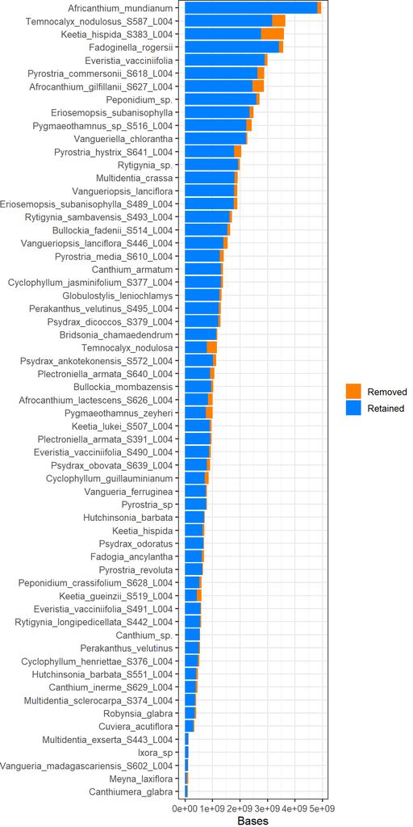

Figure 1. Trimming stats

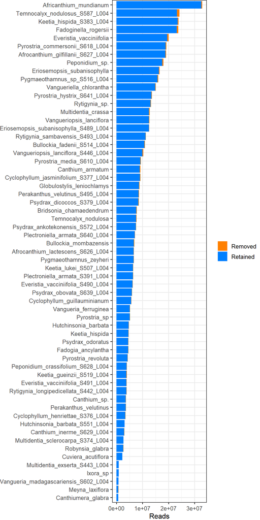

Figure 1. Trimming stats

| sample_name | bases_input | bases_passed_cleaning | bases_output_p | bases_trimmed_p | reads_input | reads_passed_cleaning | reads_output_p | reads_trimmed_p | after_seq_len | before_seq_len | pct_seq_len_after | pct_seq_len_change |
| --- | --- | --- | --- | --- | --- | --- | --- | --- | --- | --- | --- | --- |
| Psydrax_odoratus | 691336588 | 673907166 | 97.48 | 2.52 | 4578388 | 4500108 | 98.29 | 1.71 | 149.75 | 151.00 | 99.17 | -0.83 |
| Vangueriella_chlorantha | 2278873531 | 2217423169 | 97.30 | 2.70 | 15132996 | 14937508 | 98.71 | 1.29 | 148.45 | 150.59 | 98.58 | -1.42 |
| Africanthium_mundianum | 4959347212 | 4821151266 | 97.21 | 2.79 | 32934218 | 32570264 | 98.89 | 1.11 | 148.02 | 150.58 | 98.30 | -1.70 |
| Bridsonia_chamaedendrum | 1170761212 | 1135063694 | 96.95 | 3.05 | 7775218 | 7655776 | 98.46 | 1.54 | 148.26 | 150.58 | 98.46 | -1.54 |
| Pyrostria_sp | 792146906 | 767700073 | 96.91 | 3.09 | 5246006 | 5152572 | 98.22 | 1.78 | 148.99 | 151.00 | 98.67 | -1.33 |
| Pyrostria_revoluta | 651196862 | 630437340 | 96.81 | 3.19 | 4312562 | 4220268 | 97.86 | 2.14 | 149.38 | 151.00 | 98.93 | -1.07 |
| Everistia_vacciniifolia | 3000000000 | 2894806980 | 96.49 | 3.51 | 20000000 | 19531030 | 97.66 | 2.34 | 148.22 | 150.00 | 98.81 | -1.19 |
| Rytigynia_sp. | 2005687510 | 1933148790 | 96.38 | 3.62 | 13319090 | 13100662 | 98.36 | 1.64 | 147.56 | 150.59 | 97.99 | -2.01 |
| Peponidium_sp. | 2711183974 | 2605417229 | 96.10 | 3.90 | 18003526 | 17594164 | 97.73 | 2.27 | 148.08 | 150.59 | 98.33 | -1.67 |
| Canthium_sp. | 554219528 | 532123195 | 96.01 | 3.99 | 3670328 | 3606570 | 98.26 | 1.74 | 147.54 | 151.00 | 97.71 | -2.29 |
| Fadoginella_rogersii | 3576164466 | 3424688836 | 95.76 | 4.24 | 23748300 | 23178942 | 97.60 | 2.40 | 147.75 | 150.59 | 98.12 | -1.88 |
| Vangueria_ferruginea | 793405944 | 757204280 | 95.44 | 4.56 | 5254344 | 5196442 | 98.90 | 1.10 | 145.72 | 151.00 | 96.50 | -3.50 |
| Hutchinsonia_barbata | 721863542 | 687935368 | 95.30 | 4.70 | 4793802 | 4733822 | 98.75 | 1.25 | 145.32 | 150.58 | 96.51 | -3.49 |
| Rytigynia_sambavensis_S493_L004 | 1707254924 | 1623177782 | 95.08 | 4.92 | 11306324 | 11169650 | 98.79 | 1.21 | 145.32 | 151.00 | 96.24 | -3.76 |
| Cyclophyllum_jasminifolium_S377_L004 | 1383674004 | 1313828341 | 94.95 | 5.05 | 9163404 | 9043870 | 98.70 | 1.30 | 145.27 | 151.00 | 96.21 | -3.79 |
| Canthium_armatum | 1387801309 | 1312894798 | 94.60 | 5.40 | 9214600 | 8976732 | 97.42 | 2.58 | 146.26 | 150.61 | 97.11 | -2.89 |
| Plectroniella_armata_S391_L004 | 967626120 | 913929151 | 94.45 | 5.55 | 6408120 | 6323846 | 98.68 | 1.32 | 144.52 | 151.00 | 95.71 | -4.29 |
| Ixora_sp | 136801500 | 129149425 | 94.41 | 5.59 | 912010 | 881598 | 96.67 | 3.33 | 146.49 | 150.00 | 97.66 | -2.34 |
| Globulostylis_leniochlamys | 1328918785 | 1250868110 | 94.13 | 5.87 | 8825192 | 8703482 | 98.62 | 1.38 | 143.72 | 150.58 | 95.44 | -4.56 |
| Multidentia_crassa | 1918545645 | 1805409309 | 94.10 | 5.90 | 12737554 | 12491414 | 98.07 | 1.93 | 144.53 | 150.62 | 95.96 | -4.04 |
| Rytigynia_longipedicellata_S442_L004 | 590239672 | 554886453 | 94.01 | 5.99 | 3908872 | 3853908 | 98.59 | 1.41 | 143.98 | 151.00 | 95.35 | -4.65 |
| Perakanthus_velutinus_S495_L004 | 1305582240 | 1227355662 | 94.01 | 5.99 | 8646240 | 8536240 | 98.73 | 1.27 | 143.78 | 151.00 | 95.22 | -4.78 |
| Eriosemopsis_subanisophylla | 2497429516 | 2346848991 | 93.97 | 6.03 | 16582814 | 16330578 | 98.48 | 1.52 | 143.71 | 150.60 | 95.42 | -4.58 |
| Everistia_vacciniifolia_S491_L004 | 596050454 | 559465166 | 93.86 | 6.14 | 3947354 | 3898910 | 98.77 | 1.23 | 143.49 | 151.00 | 95.03 | -4.97 |
| Eriosemopsis_subanisophylla_S489_L004 | 1903434124 | 1782402305 | 93.64 | 6.36 | 12605524 | 12457314 | 98.82 | 1.18 | 143.08 | 151.00 | 94.76 | -5.24 |
| Bullockia_fadenii_S514_L004 | 1649839892 | 1543017013 | 93.53 | 6.47 | 10926092 | 10792388 | 98.78 | 1.22 | 142.97 | 151.00 | 94.68 | -5.32 |
| Vangueriopsis_lanciflora | 1913185471 | 1789311644 | 93.53 | 6.47 | 12704728 | 12532830 | 98.65 | 1.35 | 142.77 | 150.59 | 94.81 | -5.19 |
| Psydrax_dicoccos_S379_L004 | 1296398118 | 1211856479 | 93.48 | 6.52 | 8585418 | 8445038 | 98.36 | 1.64 | 143.50 | 151.00 | 95.03 | -4.97 |
| Keetia_lukei_S507_L004 | 971114522 | 907038981 | 93.40 | 6.60 | 6431222 | 6340692 | 98.59 | 1.41 | 143.05 | 151.00 | 94.74 | -5.26 |
| Everistia_vacciniifolia_S490_L004 | 939160808 | 874012050 | 93.06 | 6.94 | 6219608 | 6148946 | 98.86 | 1.14 | 142.14 | 151.00 | 94.13 | -5.87 |
| Bullockia_mombazensis | 1028110069 | 953016519 | 92.70 | 7.30 | 6827046 | 6689684 | 97.99 | 2.01 | 142.46 | 150.59 | 94.60 | -5.40 |
| Perakanthus_velutinus | 550282941 | 505833007 | 91.92 | 8.08 | 3655688 | 3572330 | 97.72 | 2.28 | 141.60 | 150.53 | 94.07 | -5.93 |
| Keetia_hispida | 700704876 | 643769240 | 91.87 | 8.13 | 4652216 | 4597390 | 98.82 | 1.18 | 140.03 | 150.62 | 92.97 | -7.03 |
| Pygmaeothamnus_sp_S516_L004 | 2428682792 | 2230707276 | 91.85 | 8.15 | 16083992 | 15815944 | 98.33 | 1.67 | 141.04 | 151.00 | 93.41 | -6.59 |
| Pyrostria_commersonii_S618_L004 | 2891859890 | 2643894153 | 91.43 | 8.57 | 19151390 | 18924434 | 98.81 | 1.19 | 139.71 | 151.00 | 92.52 | -7.48 |
| Vangueriopsis_lanciflora_S446_L004 | 1557092068 | 1401606904 | 90.01 | 9.99 | 10311868 | 10016518 | 97.14 | 2.86 | 139.93 | 151.00 | 92.67 | -7.33 |
| Pyrostria_media_S610_L004 | 1413888198 | 1269237642 | 89.77 | 10.23 | 9363498 | 9179070 | 98.03 | 1.97 | 138.28 | 151.00 | 91.57 | -8.43 |
| Cyclophyllum_henriettae_S376_L004 | 523681288 | 468511589 | 89.47 | 10.53 | 3468088 | 3423132 | 98.70 | 1.30 | 136.87 | 151.00 | 90.64 | -9.36 |
| Psydrax_ankotekonensis_S572_L004 | 1138464198 | 1016750496 | 89.31 | 10.69 | 7539498 | 7458108 | 98.92 | 1.08 | 136.33 | 151.00 | 90.28 | -9.72 |
| Fadogia_ancylantha | 689347817 | 614944231 | 89.21 | 10.79 | 4576300 | 4493112 | 98.18 | 1.82 | 136.86 | 150.63 | 90.86 | -9.14 |
| Cuviera_acutiflora | 344249411 | 306356838 | 88.99 | 11.01 | 2285566 | 2243286 | 98.15 | 1.85 | 136.57 | 150.62 | 90.67 | -9.33 |
| Multidentia_sclerocarpa_S374_L004 | 412877186 | 366888905 | 88.86 | 11.14 | 2734286 | 2705070 | 98.93 | 1.07 | 135.63 | 151.00 | 89.82 | -10.18 |
| Robynsia_glabra | 403958712 | 357142856 | 88.41 | 11.59 | 2681648 | 2646724 | 98.70 | 1.30 | 134.94 | 150.64 | 89.58 | -10.42 |
| Psydrax_obovata_S639_L004 | 910089382 | 797704503 | 87.65 | 12.35 | 6027082 | 5945430 | 98.65 | 1.35 | 134.17 | 151.00 | 88.85 | -11.15 |
| Pyrostria_hystrix_S641_L004 | 2055447032 | 1791771179 | 87.17 | 12.83 | 13612232 | 13443094 | 98.76 | 1.24 | 133.29 | 151.00 | 88.27 | -11.73 |
| Temnocalyx_nodulosus_S587_L004 | 3651275130 | 3172590575 | 86.89 | 13.11 | 24180630 | 23213490 | 96.00 | 4.00 | 136.67 | 151.00 | 90.51 | -9.49 |
| Peponidium_crassifolium_S628_L004 | 603751756 | 522699584 | 86.58 | 13.42 | 3998356 | 3949430 | 98.78 | 1.22 | 132.35 | 151.00 | 87.65 | -12.35 |
| Hutchinsonia_barbata_S551_L004 | 474539546 | 408768866 | 86.14 | 13.86 | 3142646 | 3101234 | 98.68 | 1.32 | 131.81 | 151.00 | 87.29 | -12.71 |
| Afrocanthium_gilfillanii_S627_L004 | 2880593780 | 2452811741 | 85.15 | 14.85 | 19076780 | 18849784 | 98.81 | 1.19 | 130.12 | 151.00 | 86.17 | -13.83 |
| Canthium_inerme_S629_L004 | 458929468 | 390655727 | 85.12 | 14.88 | 3039268 | 2998330 | 98.65 | 1.35 | 130.29 | 151.00 | 86.29 | -13.71 |
| Plectroniella_armata_S640_L004 | 1071740318 | 911025276 | 85.00 | 15.00 | 7097618 | 7013160 | 98.81 | 1.19 | 129.90 | 151.00 | 86.03 | -13.97 |
| Vangueria_madagascariensis_S602_L004 | 118580602 | 100569579 | 84.81 | 15.19 | 785302 | 768584 | 97.87 | 2.13 | 130.85 | 151.00 | 86.66 | -13.34 |
| Cyclophyllum_guillauminianum | 860351400 | 722992991 | 84.03 | 15.97 | 5735676 | 5643176 | 98.39 | 1.61 | 128.12 | 150.00 | 85.41 | -14.59 |
| Afrocanthium_lactescens_S626_L004 | 1007677058 | 841721256 | 83.53 | 16.47 | 6673358 | 6570642 | 98.46 | 1.54 | 128.10 | 151.00 | 84.84 | -15.16 |
| Multidentia_exserta_S443_L004 | 138809468 | 113793929 | 81.98 | 18.02 | 919268 | 904428 | 98.39 | 1.61 | 125.82 | 151.00 | 83.32 | -16.68 |
| Keetia_hispida_S383_L004 | 3608216876 | 2769165520 | 76.75 | 23.25 | 23895476 | 23507240 | 98.38 | 1.62 | 117.80 | 151.00 | 78.01 | -21.99 |
| Pygmaeothamnus_zeyheri | 1004705667 | 761133201 | 75.76 | 24.24 | 6665980 | 6576426 | 98.66 | 1.34 | 115.74 | 150.72 | 76.79 | -23.21 |
| Keetia_gueinzii_S519_L004 | 600472640 | 435093494 | 72.46 | 27.54 | 3976640 | 3871260 | 97.35 | 2.65 | 112.39 | 151.00 | 74.43 | -25.57 |
| Temnocalyx_nodulosa | 1169378492 | 796236493 | 68.09 | 31.91 | 7757280 | 7541490 | 97.22 | 2.78 | 105.58 | 150.75 | 70.04 | -29.96 |
| Canthiumera_glabra | 111385441 | 74285750 | 66.69 | 33.31 | 738978 | 714390 | 96.67 | 3.33 | 103.98 | 150.73 | 68.99 | -31.01 |
| Meyna_laxiflora | 118079087 | 62707485 | 53.11 | 46.89 | 783194 | 706904 | 90.26 | 9.74 | 88.71 | 150.77 | 58.84 | -41.16 |

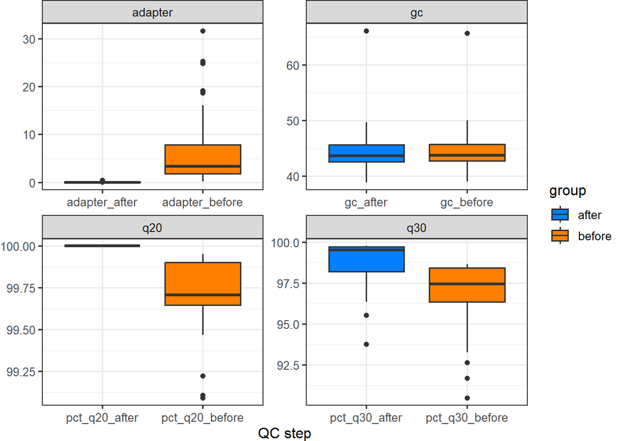

| sample_name | pct_q20_after | pct_q20_before | pct_q30_after | pct_q30_before | gc_after | gc_before | adapter_after | adapter_before |
| --- | --- | --- | --- | --- | --- | --- | --- | --- |
| Africanthium_mundianum | 100 | 99.92848 | 98.45958 | 97.44026 | 43.26694 | 43.25206 | 0.0046713 | 0.5551497 |
| Afrocanthium_gilfillanii_S627_L004 | 100 | 99.68915 | 99.73618 | 98.46667 | 42.60350 | 42.88978 | 0.0019541 | 9.3169843 |
| Afrocanthium_lactescens_S626_L004 | 100 | 99.52041 | 99.69183 | 98.16171 | 45.26222 | 45.44591 | 0.0008236 | 10.5612329 |
| Bridsonia_chamaedendrum | 100 | 99.92047 | 98.22385 | 96.96106 | 46.18597 | 46.17736 | 0.0003541 | 0.4077624 |
| Bullockia_fadenii_S514_L004 | 100 | 99.67001 | 99.73395 | 98.58875 | 43.23444 | 43.29837 | 0.0483051 | 2.7234688 |
| Bullockia_mombazensis | 100 | 99.90144 | 97.89086 | 96.24009 | 46.64484 | 46.58711 | 0.0047807 | 3.3585871 |
| Canthium_armatum | 100 | 99.91606 | 98.47455 | 96.70096 | 41.62587 | 41.99797 | 0.0008922 | 1.4768336 |
| Canthium_inerme_S629_L004 | 100 | 99.64597 | 99.70850 | 98.25165 | 46.05422 | 46.17637 | 0.0006806 | 9.5636724 |
| Canthium_sp. | 100 | 99.79405 | 96.45705 | 95.03933 | 44.64895 | 44.72029 | 0.0050374 | 0.8557143 |
| Canthiumera_glabra | 100 | 99.79363 | 97.77125 | 93.26611 | 47.33349 | 48.61488 | 0.0001934 | 25.2594916 |
| Cuviera_acutiflora | 100 | 99.87657 | 98.13599 | 96.47348 | 46.43460 | 46.28470 | 0.0003271 | 6.5084041 |
| Cyclophyllum_guillauminianum | 100 | 99.75333 | 95.54570 | 92.64169 | 44.34659 | 44.69793 | 0.0027590 | 9.3001566 |
| Cyclophyllum_henriettae_S376_L004 | 100 | 99.64537 | 99.72376 | 98.48750 | 41.41595 | 41.59330 | 0.0329932 | 5.5846791 |
| Cyclophyllum_jasminifolium_S377_L004 | 100 | 99.64597 | 99.73253 | 98.55758 | 42.36817 | 42.40833 | 0.1118575 | 1.8323505 |
| Eriosemopsis_subanisophylla | 100 | 99.94929 | 97.76819 | 96.33937 | 43.14075 | 43.19866 | 0.0003185 | 2.6034491 |
| Eriosemopsis_subanisophylla_S489_L004 | 100 | 99.68395 | 99.74519 | 98.60141 | 39.84011 | 39.94242 | 0.0368258 | 2.7182922 |
| Everistia_vacciniifolia | 100 | 99.84774 | 97.90903 | 95.93164 | 45.66985 | 45.72984 | 0.0022956 | 0.1352151 |
| Everistia_vacciniifolia_S490_L004 | 100 | 99.70738 | 99.75425 | 98.60144 | 38.89966 | 39.00780 | 0.0518486 | 3.0828849 |
| Everistia_vacciniifolia_S491_L004 | 100 | 99.67811 | 99.73521 | 98.51741 | 40.12165 | 40.21735 | 0.0704451 | 2.5693533 |
| Fadogia_ancylantha | 100 | 99.92474 | 98.56705 | 97.09064 | 45.09280 | 44.74005 | 0.0013703 | 6.5535269 |
| Fadoginella_rogersii | 100 | 99.91371 | 97.67170 | 95.93420 | 43.91583 | 43.94166 | 0.0063266 | 0.6787138 |
| Globulostylis_leniochlamys | 100 | 99.95062 | 98.51863 | 97.41275 | 49.40626 | 49.08630 | 0.0015633 | 2.9388178 |
| Hutchinsonia_barbata | 100 | 99.91927 | 98.59876 | 97.55720 | 47.53906 | 47.47594 | 0.0004366 | 1.8533016 |
| Hutchinsonia_barbata_S551_L004 | 100 | 99.65987 | 99.71805 | 98.40717 | 43.80086 | 43.95504 | 0.0009533 | 8.4441159 |
| Ixora_sp | 100 | 99.56448 | 93.77279 | 90.50416 | 45.60106 | 45.72074 | 0.0029182 | 0.4773384 |
| Keetia_gueinzii_S519_L004 | 100 | 99.22253 | 99.62935 | 97.19859 | 46.33620 | 47.25909 | 0.0019669 | 19.1663335 |
| Keetia_hispida | 100 | 99.91103 | 98.60617 | 97.45096 | 43.88335 | 43.90504 | 0.0015625 | 4.5742473 |
| Keetia_hispida_S383_L004 | 100 | 99.50163 | 99.71536 | 98.01020 | 41.36808 | 42.07725 | 0.0012633 | 16.0645523 |
| Keetia_lukei_S507_L004 | 100 | 99.59474 | 99.70494 | 98.33022 | 45.65247 | 45.72122 | 0.0932199 | 2.7035281 |
| Meyna_laxiflora | 100 | 99.46769 | 98.50319 | 91.70308 | 44.94799 | 48.55495 | 0.0002809 | 31.6375700 |
| Multidentia_crassa | 100 | 99.90737 | 98.38567 | 96.80762 | 41.40056 | 41.60616 | 0.0004453 | 2.2830067 |
| Multidentia_exserta_S443_L004 | 100 | 99.48241 | 99.66531 | 98.04638 | 40.60378 | 40.98446 | 0.1731807 | 10.9995647 |
| Multidentia_sclerocarpa_S374_L004 | 100 | 99.71536 | 99.75335 | 98.64122 | 43.20008 | 43.24889 | 0.0379829 | 5.8471917 |
| Peponidium_crassifolium_S628_L004 | 100 | 99.66386 | 99.72482 | 98.39464 | 43.19122 | 43.41487 | 0.0016442 | 8.2134475 |
| Peponidium_sp. | 100 | 99.89716 | 97.78788 | 96.13916 | 42.74057 | 42.70409 | 0.0062368 | 0.4980775 |
| Perakanthus_velutinus | 100 | 99.89143 | 97.84032 | 95.93209 | 66.12035 | 65.68665 | 0.0021200 | 3.9201558 |
| Perakanthus_velutinus_S495_L004 | 100 | 99.64892 | 99.72846 | 98.52668 | 43.56732 | 43.60470 | 0.0343014 | 2.4527115 |
| Plectroniella_armata_S391_L004 | 100 | 99.65130 | 99.72956 | 98.52632 | 40.57484 | 40.65759 | 0.1072057 | 2.2803144 |
| Plectroniella_armata_S640_L004 | 100 | 99.69697 | 99.71552 | 98.40972 | 44.95241 | 45.07981 | 0.0007782 | 9.4462639 |
| Psydrax_ankotekonensis_S572_L004 | 100 | 99.73366 | 99.74479 | 98.59220 | 42.32429 | 42.50280 | 0.0017271 | 6.2480473 |
| Psydrax_dicoccos_S379_L004 | 100 | 99.48625 | 99.69390 | 98.20720 | 40.13268 | 40.19611 | 0.2050585 | 2.6964910 |
| Psydrax_obovata_S639_L004 | 100 | 99.59705 | 99.72118 | 98.40734 | 43.77623 | 43.91060 | 0.0008033 | 7.2146167 |
| Psydrax_odoratus | 100 | 99.78975 | 97.05487 | 95.88823 | 43.15195 | 43.17453 | 0.0039824 | 0.1509786 |
| Pygmaeothamnus_sp_S516_L004 | 100 | 99.54307 | 99.70090 | 98.23662 | 43.53835 | 43.69817 | 0.3445095 | 4.0828381 |
| Pygmaeothamnus_zeyheri | 100 | 99.92565 | 98.44761 | 96.30383 | 38.89005 | 39.83367 | 0.0002473 | 18.6562512 |
| Pyrostria_commersonii_S618_L004 | 100 | 99.69388 | 99.74018 | 98.62919 | 42.35042 | 42.44891 | 0.0005809 | 4.2273244 |
| Pyrostria_hystrix_S641_L004 | 100 | 99.65339 | 99.73591 | 98.45599 | 42.80019 | 43.03308 | 0.0026250 | 7.8159832 |
| Pyrostria_media_S610_L004 | 100 | 99.47181 | 99.67587 | 98.09290 | 43.98124 | 44.18696 | 0.0025476 | 5.4062808 |
| Pyrostria_revoluta | 100 | 99.72724 | 96.33696 | 94.87186 | 42.56028 | 42.59922 | 0.0002764 | 0.2499199 |
| Pyrostria_sp | 100 | 99.80295 | 96.42577 | 95.08430 | 44.32442 | 44.35595 | 0.0040932 | 0.3556918 |
| Robynsia_glabra | 100 | 99.88067 | 98.54998 | 97.15421 | 43.67347 | 43.70664 | 0.0001582 | 7.2796483 |
| Rytigynia_longipedicellata_S442_L004 | 100 | 99.64806 | 99.71995 | 98.51724 | 44.34714 | 44.40103 | 0.2442435 | 2.5103143 |
| Rytigynia_sambavensis_S493_L004 | 100 | 99.67274 | 99.72956 | 98.58569 | 43.06110 | 43.13184 | 0.0467342 | 1.7925543 |
| Rytigynia_sp. | 100 | 99.93147 | 98.35641 | 97.07110 | 45.07309 | 44.97582 | 0.0012338 | 0.8043209 |
| Temnocalyx_nodulosa | 100 | 99.90271 | 98.39606 | 95.28407 | 48.51752 | 48.83899 | 0.0011520 | 24.7512108 |
| Temnocalyx_nodulosus_S587_L004 | 100 | 99.09209 | 99.52995 | 97.28203 | 49.64953 | 50.03330 | 0.0012788 | 6.3032507 |
| Vangueria_ferruginea | 100 | 99.88628 | 97.31445 | 96.36238 | 43.09043 | 43.13387 | 0.0017634 | 1.7442766 |
| Vangueria_madagascariensis_S602_L004 | 100 | 99.56221 | 99.69515 | 97.97708 | 46.01018 | 46.14295 | 0.0016013 | 8.9502328 |
| Vangueriella_chlorantha | 100 | 99.93252 | 98.30100 | 97.12891 | 42.89975 | 42.88831 | 0.0003279 | 0.3438769 |
| Vangueriopsis_lanciflora | 100 | 99.93727 | 98.19412 | 97.00205 | 46.31092 | 46.29568 | 0.0002199 | 3.0526621 |
| Vangueriopsis_lanciflora_S446_L004 | 100 | 99.10883 | 99.57761 | 97.46905 | 42.70416 | 42.76770 | 0.4624222 | 4.6737688 |

## 4.2 De-Novo Assembly

The shortest contigs varied from 137 bp to 248 bp, while the longest contigs were between 464,750 bp and 969 bp. The longest contigs from dataset 1 were at least 8,104 bp long, while the majority of the longest contigs from dataset 3 were smaller than that.

## 4.3 Mapping and extracting reference markers

| sample_name | NUC_n | NUC_pct | PTD_n | PTD_pct | MIT_n | MIT_pct |
| --- | --- | --- | --- | --- | --- | --- |
| Africanthium_mundianum | 342 | 97.15909 | 24 | 30.00 | 5 | 11.627907 |
| Afrocanthium_lactescens_S626_L004 | 351 | 99.71591 | 80 | 100.00 | 37 | 86.046512 |
| Bullockia_fadenii_S514_L004 | 352 | 100.00000 | 80 | 100.00 | 42 | 97.674419 |
| Canthium_armatum | 348 | 98.86364 | 72 | 90.00 | 18 | 41.860465 |
| Canthium_inerme_S629_L004 | 344 | 97.72727 | 76 | 95.00 | 41 | 95.348837 |
| Canthium_sp. | NA | NA | 44 | 55.00 | 10 | 23.255814 |
| Cyclophyllum_guillauminianum | 316 | 89.77273 | 63 | 78.75 | 15 | 34.883721 |
| Cyclophyllum_henriettae_S376_L004 | 346 | 98.29545 | 80 | 100.00 | 42 | 97.674419 |
| Cyclophyllum_jasminifolium_S377_L004 | 350 | 99.43182 | 80 | 100.00 | 42 | 97.674419 |
| Eriosemopsis_subanisophylla | 339 | 96.30682 | 65 | 81.25 | 4 | 9.302326 |
| Eriosemopsis_subanisophylla_S489_L004 | 350 | 99.43182 | 80 | 100.00 | 42 | 97.674419 |
| Everistia_vacciniifolia | 348 | 98.86364 | 76 | 95.00 | 41 | 95.348837 |
| Everistia_vacciniifolia_S490_L004 | 349 | 99.14773 | 80 | 100.00 | 42 | 97.674419 |
| Everistia_vacciniifolia_S491_L004 | 349 | 99.14773 | 80 | 100.00 | 42 | 97.674419 |
| Fadogia_ancylantha | 334 | 94.88636 | 62 | 77.50 | 4 | 9.302326 |
| Globulostylis_leniochlamys | 341 | 96.87500 | 72 | 90.00 | 7 | 16.279070 |
| Hutchinsonia_barbata_S551_L004 | 344 | 97.72727 | 79 | 98.75 | 14 | 32.558140 |
| Ixora_sp | 231 | 65.62500 | 15 | 18.75 | 1 | 2.325581 |
| Keetia_gueinzii_S519_L004 | 281 | 79.82955 | 74 | 92.50 | 24 | 55.813953 |
| Keetia_hispida_S383_L004 | 347 | 98.57955 | 80 | 100.00 | 43 | 100.000000 |
| Keetia_lukei_S507_L004 | 325 | 92.32955 | 68 | 85.00 | 23 | 53.488372 |
| Multidentia_crassa | 344 | 97.72727 | 80 | 100.00 | 34 | 79.069767 |
| Multidentia_exserta_S443_L004 | 331 | 94.03409 | 55 | 68.75 | 9 | 20.930233 |
| Multidentia_sclerocarpa_S374_L004 | 346 | 98.29545 | 80 | 100.00 | 41 | 95.348837 |
| Peponidium_crassifolium_S628_L004 | 349 | 99.14773 | 80 | 100.00 | 40 | 93.023256 |
| Perakanthus_velutinus_S495_L004 | 350 | 99.43182 | 80 | 100.00 | 40 | 93.023256 |
| Plectroniella_armata_S391_L004 | 352 | 100.00000 | 80 | 100.00 | 41 | 95.348837 |
| Plectroniella_armata_S640_L004 | 349 | 99.14773 | 79 | 98.75 | 41 | 95.348837 |
| Psydrax_ankotekonensis_S572_L004 | 349 | 99.14773 | 80 | 100.00 | 42 | 97.674419 |
| Psydrax_dicoccos_S379_L004 | 350 | 99.43182 | 80 | 100.00 | 39 | 90.697674 |
| Psydrax_obovata_S639_L004 | 349 | 99.14773 | 79 | 98.75 | 38 | 88.372093 |
| Psydrax_odoratus | 345 | 98.01136 | 80 | 100.00 | 40 | 93.023256 |
| Pygmaeothamnus_sp_S516_L004 | 347 | 98.57955 | 80 | 100.00 | 42 | 97.674419 |
| Pyrostria_commersonii_S618_L004 | 351 | 99.71591 | 80 | 100.00 | 42 | 97.674419 |
| Pyrostria_hystrix_S641_L004 | 350 | 99.43182 | 80 | 100.00 | 42 | 97.674419 |
| Pyrostria_media_S610_L004 | 351 | 99.71591 | 80 | 100.00 | 42 | 97.674419 |
| Pyrostria_revoluta | NA | NA | NA | NA | 31 | 72.093023 |
| Pyrostria_sp | 345 | 98.01136 | 28 | 35.00 | 12 | 27.906977 |
| Rytigynia_longipedicellata_S442_L004 | 350 | 99.43182 | 80 | 100.00 | 42 | 97.674419 |
| Rytigynia_sambavensis_S493_L004 | 352 | 100.00000 | 80 | 100.00 | 42 | 97.674419 |
| Rytigynia_sp. | 345 | 98.01136 | 29 | 36.25 | 2 | 4.651163 |
| Temnocalyx_nodulosa | 325 | 92.32955 | 80 | 100.00 | 31 | 72.093023 |
| Temnocalyx_nodulosus_S587_L004 | 349 | 99.14773 | 80 | 100.00 | 42 | 97.674419 |
| Vangueria_ferruginea | 343 | 97.44318 | 56 | 70.00 | 15 | 34.883721 |
| Vangueria_madagascariensis_S602_L004 | 336 | 95.45455 | 11 | 13.75 | 2 | 4.651163 |
| Vangueriella_chlorantha | 344 | 97.72727 | 3 | 3.75 | 1 | 2.325581 |
| Vangueriopsis_lanciflora_S446_L004 | 350 | 99.43182 | 80 | 100.00 | 42 | 97.674419 |
| Bridsonia_chamaedendrum | 334 | 94.88636 | 3 | 3.75 | NA | NA |
| Bullockia_mombazensis | 333 | 94.60227 | NA | NA | NA | NA |
| Canthiumera_glabra | 124 | 35.22727 | NA | NA | NA | NA |
| Cuviera_acutiflora | 290 | 82.38636 | 2 | 2.50 | NA | NA |
| Fadoginella_rogersii | 338 | 96.02273 | 1 | 1.25 | NA | NA |
| Hutchinsonia_barbata | 337 | 95.73864 | 1 | 1.25 | NA | NA |
| Keetia_hispida | 338 | 96.02273 | 1 | 1.25 | NA | NA |
| Meyna_laxiflora | 223 | 63.35227 | 3 | 3.75 | NA | NA |
| Peponidium_sp. | 341 | 96.87500 | 2 | 2.50 | NA | NA |
| Perakanthus_velutinus | 101 | 28.69318 | NA | NA | NA | NA |
| Pygmaeothamnus_zeyheri | 317 | 90.05682 | 27 | 33.75 | NA | NA |
| Robynsia_glabra | 336 | 95.45455 | 3 | 3.75 | NA | NA |
| Vangueriopsis_lanciflora | 336 | 95.45455 | 1 | 1.25 | NA | NA |
| Afrocanthium_gilfillanii_S627_L004 | NA | NA | 80 | 100.00 | NA | NA |

| sample_name | median_recovery_MIT | median_recovery_NUC | median_recovery_PTD | mean_recovery_MIT | mean_recovery_NUC | mean_recovery_PTD |
| --- | --- | --- | --- | --- | --- | --- |
| Africanthium_mundianum | 28.330 | 82.090 | 72.000 | 35.67600 | 77.60026 | 65.87880 |
| Afrocanthium_gilfillanii_S627_L004 | NA | NA | 100.000 | NA | NA | 99.74062 |
| Afrocanthium_lactescens_S626_L004 | 88.840 | 83.235 | 100.000 | 81.22436 | 79.79785 | 99.48750 |
| Bridsonia_chamaedendrum | NA | 74.670 | 32.430 | NA | 71.65784 | 49.45000 |
| Bullockia_fadenii_S514_L004 | 100.000 | 83.860 | 100.000 | 98.77512 | 78.96365 | 98.52329 |
| Bullockia_mombazensis | NA | 71.550 | NA | NA | 68.20511 | NA |
| Canthium_armatum | 57.470 | 78.950 | 100.000 | 61.38833 | 73.95914 | 91.85466 |
| Canthium_inerme_S629_L004 | 99.170 | 79.220 | 100.000 | 86.64756 | 75.17524 | 98.69763 |
| Canthium_sp. | 41.025 | NA | 65.440 | 48.87200 | NA | 64.00469 |
| Canthiumera_glabra | NA | 34.115 | NA | NA | 40.28898 | NA |
| Cuviera_acutiflora | NA | 56.540 | 59.670 | NA | 58.90540 | 59.67000 |
| Cyclophyllum_guillauminianum | 62.210 | 65.740 | 80.430 | 59.35867 | 64.94202 | 78.01211 |
| Cyclophyllum_henriettae_S376_L004 | 99.580 | 81.395 | 100.000 | 91.70136 | 76.66675 | 98.23226 |
| Cyclophyllum_jasminifolium_S377_L004 | 97.680 | 85.110 | 100.000 | 90.72786 | 80.14661 | 99.65671 |
| Eriosemopsis_subanisophylla | 55.030 | 76.030 | 92.930 | 50.98000 | 71.80351 | 82.94062 |
| Eriosemopsis_subanisophylla_S489_L004 | 100.000 | 79.770 | 100.000 | 98.65182 | 75.76806 | 99.62587 |
| Everistia_vacciniifolia | 100.000 | 84.175 | 96.575 | 93.71262 | 78.43717 | 86.78557 |
| Everistia_vacciniifolia_S490_L004 | 100.000 | 82.690 | 100.000 | 90.18085 | 78.41518 | 92.38505 |
| Everistia_vacciniifolia_S491_L004 | 92.220 | 83.875 | 100.000 | 82.43830 | 79.20918 | 92.59413 |
| Fadogia_ancylantha | 25.715 | 72.290 | 85.590 | 35.69000 | 70.04467 | 78.62156 |
| Fadoginella_rogersii | NA | 75.510 | 56.760 | NA | 72.41632 | 56.76000 |
| Globulostylis_leniochlamys | 51.220 | 79.255 | 93.650 | 50.33143 | 74.13495 | 86.25375 |
| Hutchinsonia_barbata | NA | 78.150 | 21.620 | NA | 74.05591 | 21.62000 |
| Hutchinsonia_barbata_S551_L004 | 65.170 | 79.570 | 100.000 | 66.58643 | 76.32668 | 94.30074 |
| Ixora_sp | 27.700 | 43.750 | 53.850 | 27.70000 | 48.38561 | 58.23947 |
| Keetia_gueinzii_S519_L004 | 76.935 | 57.300 | 100.000 | 70.01667 | 59.35646 | 87.70458 |
| Keetia_hispida | NA | 75.045 | 62.160 | NA | 71.26872 | 62.16000 |
| Keetia_hispida_S383_L004 | 100.000 | 82.590 | 100.000 | 95.99565 | 77.73416 | 94.50167 |
| Keetia_lukei_S507_L004 | 84.630 | 67.380 | 86.360 | 77.39913 | 66.31178 | 78.03573 |
| Meyna_laxiflora | NA | 43.840 | 31.630 | NA | 48.12562 | 48.31000 |
| Multidentia_crassa | 75.945 | 83.270 | 100.000 | 71.00167 | 77.51428 | 99.48900 |
| Multidentia_exserta_S443_L004 | 33.840 | 70.090 | 75.555 | 41.86222 | 68.15821 | 72.44196 |
| Multidentia_sclerocarpa_S374_L004 | 99.000 | 81.310 | 100.000 | 89.96512 | 76.46454 | 97.77134 |
| Peponidium_crassifolium_S628_L004 | 99.745 | 81.585 | 100.000 | 91.88524 | 77.50241 | 99.68037 |
| Peponidium_sp. | NA | 73.325 | 41.700 | NA | 70.82506 | 41.70000 |
| Perakanthus_velutinus | NA | 38.500 | NA | NA | 43.17048 | NA |
| Perakanthus_velutinus_S495_L004 | 95.240 | 85.735 | 100.000 | 87.53667 | 80.91196 | 99.71537 |
| Plectroniella_armata_S391_L004 | 99.875 | 84.310 | 100.000 | 92.41545 | 79.54607 | 99.72437 |
| Plectroniella_armata_S640_L004 | 97.825 | 82.830 | 100.000 | 88.11262 | 78.14897 | 95.82181 |
| Psydrax_ankotekonensis_S572_L004 | 100.000 | 84.720 | 100.000 | 97.79864 | 79.99320 | 98.23877 |
| Psydrax_dicoccos_S379_L004 | 76.340 | 84.150 | 100.000 | 73.11415 | 78.95186 | 98.43476 |
| Psydrax_obovata_S639_L004 | 75.730 | 83.530 | 100.000 | 72.33256 | 78.88593 | 93.09524 |
| Psydrax_odoratus | 100.000 | 80.585 | 100.000 | 94.47477 | 76.50975 | 96.71798 |
| Pygmaeothamnus_sp_S516_L004 | 89.900 | 77.810 | 100.000 | 83.32333 | 73.79926 | 94.80212 |
| Pygmaeothamnus_zeyheri | NA | 67.150 | 50.000 | NA | 64.67734 | 50.37481 |
| Pyrostria_commersonii_S618_L004 | 100.000 | 84.885 | 100.000 | 98.82395 | 81.25905 | 99.74400 |
| Pyrostria_hystrix_S641_L004 | 100.000 | 84.620 | 100.000 | 97.93455 | 79.53017 | 99.74400 |
| Pyrostria_media_S610_L004 | 100.000 | 84.720 | 100.000 | 99.05837 | 79.42653 | 95.10882 |
| Pyrostria_revoluta | 63.895 | NA | NA | 60.00281 | NA | NA |
| Pyrostria_sp | 51.280 | 76.250 | 60.170 | 56.07000 | 72.19700 | 62.68667 |
| Robynsia_glabra | NA | 70.695 | 30.300 | NA | 69.61774 | 38.12000 |
| Rytigynia_longipedicellata_S442_L004 | 99.850 | 83.160 | 100.000 | 91.51318 | 79.19516 | 98.74915 |
| Rytigynia_sambavensis_S493_L004 | 97.235 | 87.885 | 100.000 | 85.77120 | 83.01418 | 99.68750 |
| Rytigynia_sp. | 50.470 | 81.610 | 63.050 | 50.47000 | 77.62188 | 62.28621 |
| Temnocalyx_nodulosa | 62.640 | 69.550 | 100.000 | 67.39677 | 66.96425 | 98.09659 |
| Temnocalyx_nodulosus_S587_L004 | 100.000 | 85.805 | 100.000 | 95.83104 | 81.08627 | 97.67590 |
| Vangueria_ferruginea | 45.700 | 80.850 | 67.020 | 52.70294 | 75.62990 | 69.68138 |
| Vangueria_madagascariensis_S602_L004 | 72.000 | 71.550 | 67.500 | 72.00000 | 70.07517 | 62.84273 |
| Vangueriella_chlorantha | 47.780 | 83.140 | 51.760 | 47.78000 | 77.63216 | 51.98333 |
| Vangueriopsis_lanciflora | NA | 72.685 | 29.730 | NA | 70.78983 | 29.73000 |
| Vangueriopsis_lanciflora_S446_L004 | 100.000 | 85.125 | 100.000 | 91.88476 | 81.17851 | 96.23581 |

| sample_name | pct_gt50_MIT | pct_gt50_NUC | pct_gt50_PTD | pct_gt75_MIT | pct_gt75_NUC | pct_gt75_PTD | pct_gt90_MIT | pct_gt90_NUC | pct_gt90_PTD |
| --- | --- | --- | --- | --- | --- | --- | --- | --- | --- |
| Africanthium_mundianum | 20.00000 | 87.58950 | 72.00000 | 0.00000 | 62.76850 | 32.00000 | 0.000000 | 35.322196 | 20.000000 |
| Afrocanthium_gilfillanii_S627_L004 | NA | NA | 100.00000 | NA | NA | 100.00000 | NA | NA | 98.750000 |
| Afrocanthium_lactescens_S626_L004 | 89.74359 | 92.19512 | 100.00000 | 71.79487 | 68.04878 | 98.75000 | 46.153846 | 37.317073 | 98.750000 |
| Bridsonia_chamaedendrum | NA | 80.39702 | 33.33333 | NA | 49.37965 | 33.33333 | NA | 25.062035 | 0.000000 |
| Bullockia_fadenii_S514_L004 | 100.00000 | 90.07444 | 97.64706 | 97.67442 | 67.74194 | 97.64706 | 97.674419 | 35.235732 | 97.647059 |
| Bullockia_mombazensis | NA | 74.10072 | NA | NA | 43.40528 | NA | NA | 23.741007 | NA |
| Canthium_armatum | 66.66667 | 83.03393 | 97.26027 | 27.77778 | 55.88822 | 89.04110 | 22.222222 | 28.343313 | 72.602740 |
| Canthium_inerme_S629_L004 | 92.68293 | 87.68116 | 100.00000 | 80.48780 | 57.00483 | 97.36842 | 63.414634 | 28.502416 | 97.368421 |
| Canthium_sp. | 30.00000 | NA | 67.34694 | 20.00000 | NA | 34.69388 | 0.000000 | NA | 20.408163 |
| Canthiumera_glabra | NA | 21.87500 | NA | NA | 6.25000 | NA | NA | 3.906250 | NA |
| Cuviera_acutiflora | NA | 56.59824 | 100.00000 | NA | 27.85924 | 0.00000 | NA | 13.196481 | 0.000000 |
| Cyclophyllum_guillauminianum | 66.66667 | 73.29545 | 85.91549 | 26.66667 | 37.21591 | 59.15493 | 6.666667 | 17.045455 | 43.661972 |
| Cyclophyllum_henriettae_S376_L004 | 95.45455 | 89.00000 | 98.80952 | 86.36364 | 60.50000 | 96.42857 | 75.000000 | 31.250000 | 96.428571 |
| Cyclophyllum_jasminifolium_S377_L004 | 97.61905 | 90.27431 | 100.00000 | 85.71429 | 66.83292 | 100.00000 | 73.809524 | 38.902743 | 100.000000 |
| Eriosemopsis_subanisophylla | 50.00000 | 80.38835 | 90.76923 | 0.00000 | 51.45631 | 69.23077 | 0.000000 | 27.572816 | 50.769231 |
| Eriosemopsis_subanisophylla_S489_L004 | 100.00000 | 83.81113 | 100.00000 | 97.72727 | 59.02192 | 100.00000 | 97.727273 | 32.040472 | 98.750000 |
| Everistia_vacciniifolia | 97.61905 | 87.94643 | 93.18182 | 90.47619 | 63.83929 | 79.54545 | 85.714286 | 38.839286 | 59.090909 |
| Everistia_vacciniifolia_S490_L004 | 93.61702 | 89.54869 | 95.60440 | 82.97872 | 63.42043 | 86.81319 | 76.595745 | 34.204276 | 78.021978 |
| Everistia_vacciniifolia_S491_L004 | 89.36170 | 89.90385 | 95.65217 | 72.34043 | 65.38462 | 88.04348 | 55.319149 | 36.778846 | 77.173913 |
| Fadogia_ancylantha | 25.00000 | 78.93333 | 85.93750 | 0.00000 | 45.86667 | 65.62500 | 0.000000 | 25.066667 | 42.187500 |
| Fadoginella_rogersii | NA | 82.32446 | 100.00000 | NA | 51.57385 | 0.00000 | NA | 28.087167 | 0.000000 |
| Globulostylis_leniochlamys | 57.14286 | 82.83582 | 91.66667 | 14.28571 | 55.72139 | 77.77778 | 0.000000 | 31.094527 | 58.333333 |
| Hutchinsonia_barbata | NA | 85.34704 | 0.00000 | NA | 53.98458 | 0.00000 | NA | 27.506427 | 0.000000 |
| Hutchinsonia_barbata_S551_L004 | 71.42857 | 89.46015 | 96.29630 | 35.71429 | 58.09769 | 91.35802 | 21.428571 | 28.277635 | 82.716049 |
| Ixora_sp | 0.00000 | 39.13043 | 68.42105 | 0.00000 | 14.62451 | 26.31579 | 0.000000 | 4.743083 | 15.789474 |
| Keetia_gueinzii_S519_L004 | 75.00000 | 59.07692 | 96.38554 | 50.00000 | 28.92308 | 79.51807 | 25.000000 | 13.538462 | 63.855422 |
| Keetia_hispida | NA | 81.73516 | 100.00000 | NA | 50.00000 | 0.00000 | NA | 25.799087 | 0.000000 |
| Keetia_hispida_S383_L004 | 97.82609 | 88.31461 | 96.66667 | 95.65217 | 62.92135 | 88.88889 | 89.130435 | 34.382022 | 85.555556 |
| Keetia_lukei_S507_L004 | 86.95652 | 72.23720 | 84.00000 | 60.86957 | 36.92722 | 61.33333 | 34.782609 | 21.563342 | 42.666667 |
| Meyna_laxiflora | NA | 40.00000 | 33.33333 | NA | 14.04255 | 33.33333 | NA | 3.829787 | 0.000000 |
| Multidentia_crassa | 80.55556 | 88.13953 | 100.00000 | 52.77778 | 61.39535 | 98.75000 | 25.000000 | 36.046512 | 98.750000 |
| Multidentia_exserta_S443_L004 | 44.44444 | 78.34225 | 76.78571 | 0.00000 | 40.37433 | 51.78571 | 0.000000 | 20.320856 | 37.500000 |
| Multidentia_sclerocarpa_S374_L004 | 95.34884 | 88.02993 | 97.56098 | 86.04651 | 60.84788 | 96.34146 | 67.441861 | 30.673317 | 95.121951 |
| Peponidium_crassifolium_S628_L004 | 100.00000 | 87.93103 | 100.00000 | 90.47619 | 63.54680 | 100.00000 | 73.809524 | 34.729064 | 98.765432 |
| Peponidium_sp. | NA | 78.57143 | 50.00000 | NA | 48.10924 | 0.00000 | NA | 25.210084 | 0.000000 |
| Perakanthus_velutinus | NA | 27.61905 | NA | NA | 10.47619 | NA | NA | 1.904762 | NA |
| Perakanthus_velutinus_S495_L004 | 95.23810 | 92.46231 | 100.00000 | 76.19048 | 69.34673 | 100.00000 | 66.666667 | 40.201005 | 98.750000 |
| Plectroniella_armata_S391_L004 | 95.45455 | 89.67033 | 100.00000 | 86.36364 | 65.93407 | 100.00000 | 79.545455 | 38.461539 | 98.750000 |
| Plectroniella_armata_S640_L004 | 95.23810 | 89.47368 | 97.59036 | 80.95238 | 65.13158 | 91.56627 | 66.666667 | 34.210526 | 87.951807 |
| Psydrax_ankotekonensis_S572_L004 | 100.00000 | 90.58824 | 97.53086 | 95.45455 | 65.64706 | 97.53086 | 95.454545 | 38.117647 | 96.296296 |
| Psydrax_dicoccos_S379_L004 | 82.92683 | 89.97613 | 100.00000 | 53.65854 | 64.20048 | 97.56098 | 29.268293 | 37.708830 | 95.121951 |
| Psydrax_obovata_S639_L004 | 79.48718 | 89.64706 | 96.34146 | 53.84615 | 65.17647 | 87.80488 | 25.641026 | 36.470588 | 81.707317 |
| Psydrax_odoratus | 97.72727 | 88.17734 | 97.75281 | 88.63636 | 59.11330 | 95.50562 | 86.363636 | 34.482759 | 92.134832 |
| Pygmaeothamnus_sp_S516_L004 | 93.75000 | 83.55856 | 96.47059 | 70.83333 | 54.27928 | 91.76471 | 50.000000 | 29.054054 | 87.058824 |
| Pygmaeothamnus_zeyheri | NA | 71.84211 | 51.85185 | NA | 38.68421 | 14.81481 | NA | 16.842105 | 3.703704 |
| Pyrostria_commersonii_S618_L004 | 100.00000 | 93.28358 | 100.00000 | 97.67442 | 70.39801 | 100.00000 | 97.674419 | 40.547264 | 98.750000 |
| Pyrostria_hystrix_S641_L004 | 100.00000 | 90.70905 | 100.00000 | 95.45455 | 68.21516 | 100.00000 | 95.454545 | 36.430318 | 98.750000 |
| Pyrostria_media_S610_L004 | 100.00000 | 89.15663 | 96.77419 | 97.67442 | 66.74699 | 90.32258 | 97.674419 | 39.518072 | 89.247312 |
| Pyrostria_revoluta | 59.37500 | NA | NA | 34.37500 | NA | NA | 15.625000 | NA | NA |
| Pyrostria_sp | 50.00000 | 81.95122 | 63.33333 | 25.00000 | 51.21951 | 33.33333 | 16.666667 | 26.341463 | 16.666667 |
| Robynsia_glabra | NA | 80.23810 | 33.33333 | NA | 43.57143 | 0.00000 | NA | 22.380952 | 0.000000 |
| Rytigynia_longipedicellata_S442_L004 | 95.45455 | 90.46455 | 98.78049 | 86.36364 | 66.74817 | 97.56098 | 77.272727 | 34.963325 | 97.560976 |
| Rytigynia_sambavensis_S493_L004 | 92.00000 | 93.06931 | 100.00000 | 74.00000 | 75.49505 | 100.00000 | 60.000000 | 45.297030 | 98.750000 |
| Rytigynia_sp. | 50.00000 | 88.28125 | 55.17241 | 0.00000 | 61.97917 | 34.48276 | 0.000000 | 34.895833 | 24.137931 |
| Temnocalyx_nodulosa | 74.19355 | 72.65193 | 98.78049 | 29.03226 | 41.43646 | 97.56098 | 19.354839 | 18.784530 | 93.902439 |
| Temnocalyx_nodulosus_S587_L004 | 97.91667 | 91.79104 | 96.38554 | 91.66667 | 70.89552 | 96.38554 | 89.583333 | 40.547264 | 96.385542 |
| Vangueria_ferruginea | 41.17647 | 87.79221 | 75.86207 | 17.64706 | 58.18182 | 43.10345 | 17.647059 | 31.948052 | 32.758621 |
| Vangueria_madagascariensis_S602_L004 | 50.00000 | 80.37135 | 63.63636 | 50.00000 | 44.82759 | 36.36364 | 50.000000 | 24.668435 | 18.181818 |
| Vangueriella_chlorantha | 0.00000 | 88.86256 | 100.00000 | 0.00000 | 61.61137 | 0.00000 | 0.000000 | 35.071090 | 0.000000 |
| Vangueriopsis_lanciflora | NA | 80.18868 | 0.00000 | NA | 46.93396 | 0.00000 | NA | 24.292453 | 0.000000 |
| Vangueriopsis_lanciflora_S446_L004 | 97.61905 | 93.36493 | 97.67442 | 90.47619 | 67.77251 | 91.86047 | 71.428571 | 40.284360 | 89.534884 |

| sample_name | median_cov_MIT | median_cov_NUC | median_cov_PTD | mean_cov_MIT | mean_cov_NUC | mean_cov_PTD |
| --- | --- | --- | --- | --- | --- | --- |
| Africanthium_mundianum | 145.06580 | 3264.5423 | 129.33070 | 296.926780 | 3785.17111 | 161.439348 |
| Afrocanthium_gilfillanii_S627_L004 | NA | NA | 579.88980 | NA | NA | 771.574376 |
| Afrocanthium_lactescens_S626_L004 | 13.50000 | 274.8333 | 120.00000 | 18.171549 | 330.85100 | 253.732129 |
| Bridsonia_chamaedendrum | NA | 787.2663 | 338.02080 | NA | 857.37235 | 1919.522567 |
| Bullockia_fadenii_S514_L004 | 54.00000 | 683.6667 | 369.00000 | 88.989700 | 799.83067 | 478.956551 |
| Bullockia_mombazensis | NA | 804.2027 | NA | NA | 876.40028 | NA |
| Canthium_armatum | 35.90215 | 490.7434 | 50.07680 | 36.674422 | 638.81896 | 59.781269 |
| Canthium_inerme_S629_L004 | 25.25000 | 119.8333 | 146.00000 | 25.013585 | 157.03738 | 249.334899 |
| Canthium_sp. | 20.30675 | NA | 12.91740 | 23.106450 | NA | 33.869369 |
| Canthiumera_glabra | NA | 110.7362 | NA | NA | 120.35493 | NA |
| Cuviera_acutiflora | NA | 597.2351 | 320.16440 | NA | 652.93449 | 320.164400 |
| Cyclophyllum_guillauminianum | 20.75470 | 176.5035 | 26.69490 | 99.263453 | 199.84063 | 36.293321 |
| Cyclophyllum_henriettae_S376_L004 | 16.00000 | 106.1667 | 49.97450 | 20.496211 | 124.36907 | 56.325338 |
| Cyclophyllum_jasminifolium_S377_L004 | 27.37500 | 657.0000 | 72.50000 | 37.779460 | 799.33211 | 96.282191 |
| Eriosemopsis_subanisophylla | 75.51490 | 1210.6841 | 72.95810 | 81.110800 | 1476.38391 | 232.010598 |
| Eriosemopsis_subanisophylla_S489_L004 | 26.50825 | 440.7783 | 577.53610 | 51.853657 | 526.21996 | 528.327725 |
| Everistia_vacciniifolia | 164.49550 | 326.5245 | 26.63960 | 279.475221 | 425.17783 | 52.975260 |
| Everistia_vacciniifolia_S490_L004 | 13.00000 | 215.0000 | 20.00000 | 14.047011 | 239.98828 | 25.944054 |
| Everistia_vacciniifolia_S491_L004 | 9.00000 | 217.8333 | 12.25000 | 10.268538 | 249.09918 | 17.460175 |
| Fadogia_ancylantha | 71.94205 | 588.1462 | 61.12975 | 86.771925 | 640.73686 | 85.497450 |
| Fadoginella_rogersii | NA | 2406.1018 | 1131.93830 | NA | 2692.95092 | 1131.938300 |
| Globulostylis_leniochlamys | 50.68030 | 574.9238 | 84.30140 | 75.892600 | 701.38261 | 113.948463 |
| Hutchinsonia_barbata | NA | 497.9508 | 44.44440 | NA | 611.44266 | 44.444400 |
| Hutchinsonia_barbata_S551_L004 | 9.00000 | 119.5000 | 31.00000 | 10.130950 | 137.28800 | 34.534979 |
| Ixora_sp | 5.10200 | 11.1940 | 5.80580 | 5.102000 | 13.06375 | 8.787284 |
| Keetia_gueinzii_S519_L004 | 14.50000 | 43.0000 | 22.00000 | 35.932592 | 81.48559 | 34.881410 |
| Keetia_hispida | NA | 519.5404 | 127.27270 | NA | 622.23134 | 127.272700 |
| Keetia_hispida_S383_L004 | 62.90610 | 501.7460 | 100.91740 | 67.733613 | 600.15904 | 114.661496 |
| Keetia_lukei_S507_L004 | 41.00000 | 81.0000 | 14.00000 | 40.017883 | 214.01255 | 19.031928 |
| Meyna_laxiflora | NA | 143.7265 | 33.33330 | NA | 157.96310 | 36.512833 |
| Multidentia_crassa | 35.72440 | 788.4123 | 110.14760 | 40.015436 | 927.46982 | 130.528746 |
| Multidentia_exserta_S443_L004 | 5.00000 | 61.0000 | 6.50000 | 5.277778 | 67.79970 | 6.677084 |
| Multidentia_sclerocarpa_S374_L004 | 15.00000 | 136.0000 | 80.50000 | 18.703658 | 156.50119 | 89.233393 |
| Peponidium_crassifolium_S628_L004 | 19.50000 | 165.7500 | 115.93920 | 21.992986 | 195.10002 | 150.012670 |
| Peponidium_sp. | NA | 1363.8598 | 310.28750 | NA | 1630.10126 | 310.287500 |
| Perakanthus_velutinus | NA | 120.0000 | NA | NA | 144.24442 | NA |
| Perakanthus_velutinus_S495_L004 | 15.50000 | 440.6667 | 237.00000 | 21.840119 | 533.85116 | 225.398160 |
| Plectroniella_armata_S391_L004 | 14.75000 | 228.0000 | 124.86560 | 15.301429 | 269.02783 | 118.264595 |
| Plectroniella_armata_S640_L004 | 36.14690 | 490.3918 | 85.87070 | 53.938121 | 625.69245 | 141.469605 |
| Psydrax_ankotekonensis_S572_L004 | 27.00000 | 337.0000 | 221.04160 | 32.181770 | 396.14099 | 276.158631 |
| Psydrax_dicoccos_S379_L004 | 18.00000 | 293.6667 | 55.96340 | 19.310037 | 340.27461 | 74.937056 |
| Psydrax_obovata_S639_L004 | 16.00000 | 368.5000 | 33.75000 | 19.391026 | 477.90966 | 44.074116 |
| Psydrax_odoratus | 43.18075 | 76.0610 | 37.52640 | 63.637186 | 89.02919 | 45.533040 |
| Pygmaeothamnus_sp_S516_L004 | 29.68460 | 518.3333 | 169.50330 | 41.457465 | 742.85495 | 287.076534 |
| Pygmaeothamnus_zeyheri | NA | 554.9923 | 63.98600 | NA | 604.29544 | 87.327541 |
| Pyrostria_commersonii_S618_L004 | 37.00000 | 600.2500 | 803.41430 | 44.123793 | 733.35506 | 713.110234 |
| Pyrostria_hystrix_S641_L004 | 46.00000 | 376.1250 | 281.94130 | 66.740334 | 465.95157 | 275.317601 |
| Pyrostria_media_S610_L004 | 45.00000 | 273.0000 | 95.38260 | 50.215456 | 336.90014 | 117.435417 |
| Pyrostria_revoluta | 22.50450 | NA | NA | 50.642238 | NA | NA |
| Pyrostria_sp | 14.50000 | 260.8333 | 7.75000 | 25.500000 | 323.13688 | 25.429867 |
| Robynsia_glabra | NA | 400.5659 | 179.17620 | NA | 468.09050 | 259.053500 |
| Rytigynia_longipedicellata_S442_L004 | 12.75000 | 126.0000 | 64.93220 | 18.389914 | 142.75679 | 76.353383 |
| Rytigynia_sambavensis_S493_L004 | 14.50885 | 570.8958 | 229.76270 | 17.558572 | 646.35556 | 175.984719 |
| Rytigynia_sp. | 115.35580 | 1094.7145 | 72.95290 | 115.355800 | 1218.33011 | 74.679272 |
| Temnocalyx_nodulosa | 27.00000 | 155.3333 | 139.14880 | 37.122110 | 172.78360 | 170.099722 |
| Temnocalyx_nodulosus_S587_L004 | 50.05860 | 297.0000 | 1886.00000 | 67.001646 | 361.90939 | 1651.105587 |
| Vangueria_ferruginea | 12.50000 | 314.0000 | 7.50000 | 21.735294 | 387.74466 | 8.682471 |
| Vangueria_madagascariensis_S602_L004 | 7.00000 | 58.0000 | 8.66670 | 7.000000 | 67.33933 | 8.878791 |
| Vangueriella_chlorantha | 136.00000 | 1039.7500 | 91.00000 | 136.000000 | 1215.87362 | 182.666667 |
| Vangueriopsis_lanciflora | NA | 1534.4614 | 570.39470 | NA | 1819.90363 | 570.394700 |
| Vangueriopsis_lanciflora_S446_L004 | 28.50000 | 518.5000 | 47.00000 | 42.864974 | 606.80108 | 64.951159 |

```
# A tibble: 61 × 2
   sample_name                        multi_hit
   <chr>                                  <int>
 1 Africanthium_mundianum                    78
 2 Afrocanthium_gilfillanii_S627_L004         0
 3 Afrocanthium_lactescens_S626_L004         61
 4 Bridsonia_chamaedendrum                   69
 5 Bullockia_fadenii_S514_L004               57
 6 Bullockia_mombazensis                     84
 7 Canthium_armatum                         154
 8 Canthium_inerme_S629_L004                 70
 9 Canthium_sp.                               5
10 Canthiumera_glabra                         4
# ℹ 51 more rows
```

```
# A tibble: 61 × 2
   sample_name                        median_contigs
   <chr>                                       <dbl>
 1 Africanthium_mundianum                          2
 2 Afrocanthium_gilfillanii_S627_L004              1
 3 Afrocanthium_lactescens_S626_L004               2
 4 Bridsonia_chamaedendrum                         2
 5 Bullockia_fadenii_S514_L004                     2
 6 Bullockia_mombazensis                           2
 7 Canthium_armatum                                2
 8 Canthium_inerme_S629_L004                       2
 9 Canthium_sp.                                    1
10 Canthiumera_glabra                              1
# ℹ 51 more rows
```

```
# A tibble: 61 × 2
   sample_name                        missing
   <chr>                                <dbl>
 1 Africanthium_mundianum                   0
 2 Afrocanthium_gilfillanii_S627_L004       0
 3 Afrocanthium_lactescens_S626_L004        0
 4 Bridsonia_chamaedendrum                  0
 5 Bullockia_fadenii_S514_L004              0
 6 Bullockia_mombazensis                    0
 7 Canthium_armatum                         0
 8 Canthium_inerme_S629_L004                0
 9 Canthium_sp.                             0
10 Canthiumera_glabra                       0
# ℹ 51 more rows
```

```
# A tibble: 469 × 2
   locus missing
   <chr>   <dbl>
 1 4471        0
 2 4527        0
 3 4691        0
 4 4724        0
 5 4744        0
 6 4757        0
 7 4793        0
 8 4796        0
 9 4802        0
10 4806        0
# ℹ 459 more rows
```

```
# A tibble: 3 × 4
  marker_type  loci recovery coverage
  <chr>       <int>    <dbl>    <dbl>
1 MIT            43     85.3     25.5
2 NUC           353     74.1    365
3 PTD            80     91.9     86.4
```

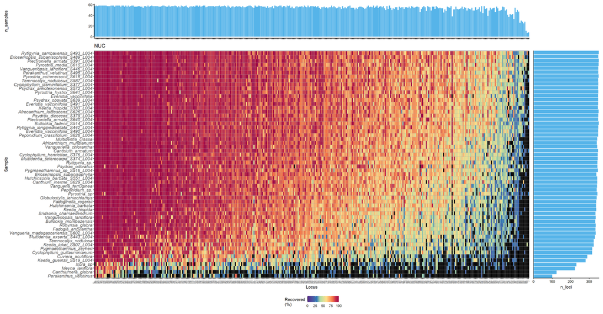

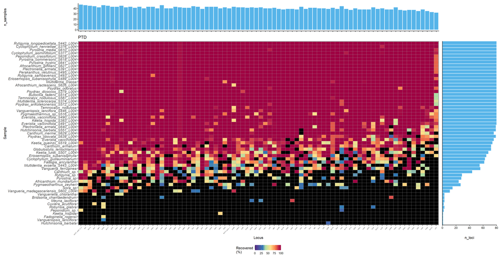

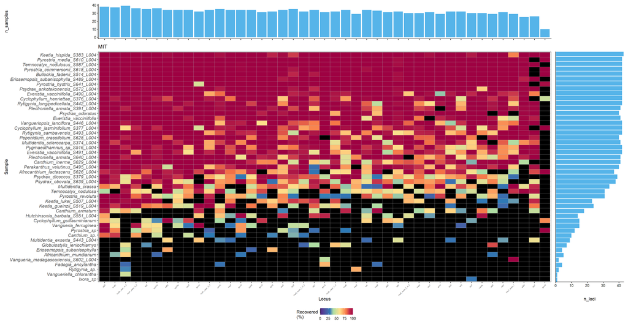

## 4.4 Alignment

Visual inspection of a random subset of 10 alignments did not show any systematic errors.

> *[NOTE] TO DO:* Increase number of visually inspected alignments

## 4.5 Phylogenetic Inference

### 4.5.1 A) Summary trees

Overall, support values were highest in the nuclear tree and branch lengths were close to zero in the plastome and the mitochondrial trees.

#### 4.5.1.1 Nuclear genes

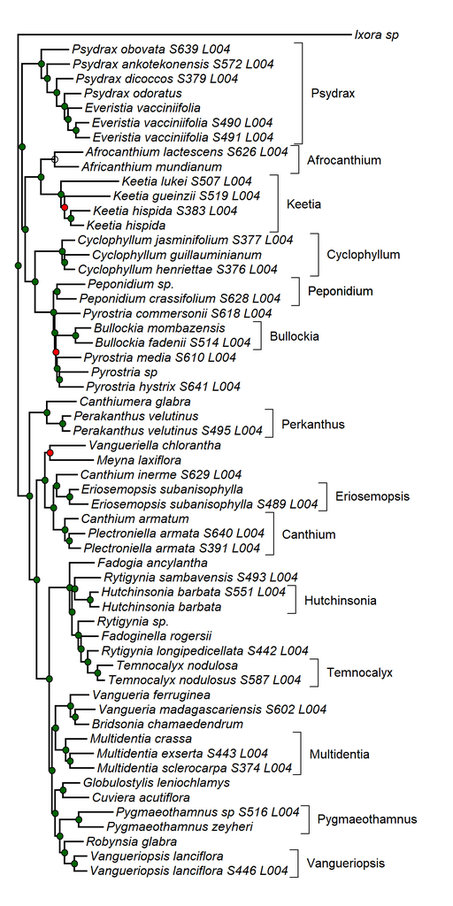

Figure 4. Concatenation-based maximum likelihood species tree for Vanguerieae based on 353 nuclear genes including the flanking regions of the genes. Nodes are colored by ultra fast bootstrap support value. Green indicates the highest support (≥ 95), orange indicates intermediate support (≥ 80) and red indicates support < 80. Species at the tips with numbers in their name are derived from dataset 1 and those without from dataset 3. “Ixora_sp” was used to root the tree. Note that the species names at the tips are the verbatim names from the herbarium vouchers. Some species have changed genus since: Everistia vacciniifolia = Psydrax vacciniifolius; Plectroniella armata = Canthium armatum; Canthium parasiebenlistii = Afrocanthium parasiebenlistii [DATASET 2 not included yet]

#### 4.5.1.2 Plastome

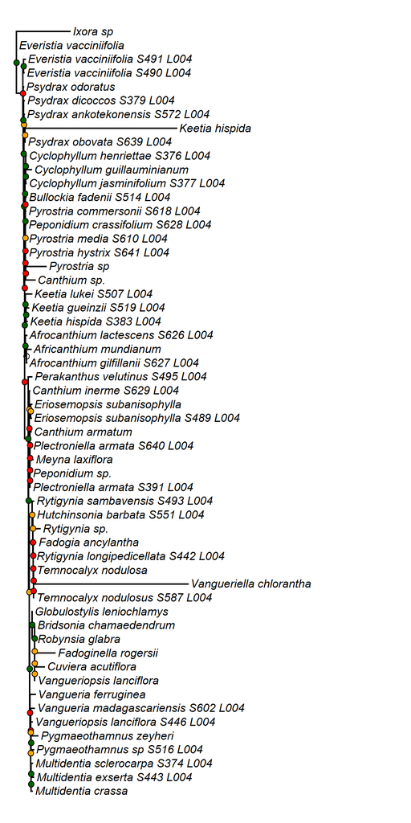